# Challenge 1: General Overview and Data Treatment

### General Trend

1. Is there a general trend in the number of snacks and drinks as the months progress from January to April? Is it the same for snacks and drinks? Why do you think that might be so?

The graph for drinks shows a general increase in daily_items across the available time frame. To better illustrate this (linear) trend, we have created a new plot. The graph for snacks shows no such trend. Instead, the trend line of the new plot for snacks is a horizontal (flat) line. The reason for the increasing trend for drinks could be related to seasonal consumption habits. Rising temperatures might stimulate the purchase of beverages without having an effect on the number of snack items sold.

```
##
## Call:
## lm(formula = y ~ x)
##
## Residuals:
##      Min       1Q   Median       3Q      Max
## -1.10281 -0.51725 -0.13027  0.47611  1.96210
##
## Coefficients:
##                Estimate  Std. Error t value  Pr(>|t|)
## (Intercept) -3.1341e+02  4.5122e+01 -6.9460 6.201e-10 ***
## x            1.8424e-02  2.6214e-03  7.0283 4.252e-10 ***
## ---
## Signif. codes:  0 '***' 0.001 '**' 0.01 '*' 0.05 '.' 0.1 ' ' 1
##
## Residual standard error: 0.64608 on 88 degrees of freedom
## Multiple R-squared:  0.35952,    Adjusted R-squared:  0.35224
## F-statistic: 49.398 on 1 and 88 DF,  p-value: 4.2516e-10
##
##
## N: 90 , AIC: 180.76 , BIC:  188.26
## Residual Sum of Squares:  36.733
```

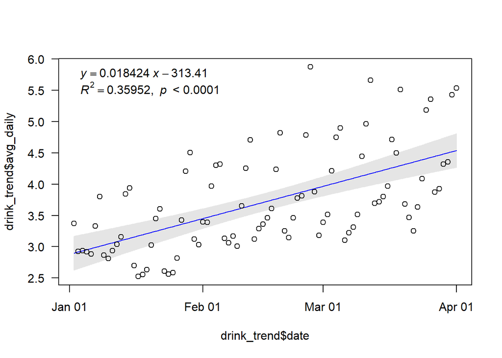

```r
drink_trend <- merged_data[type_drink_snack == 'drink',.(avg_daily=.N/uniqueN(machine)), by=(date)][order(date)]
#plot(drink_trend$date,drink_trend$avg_daily,type = "l", main = 'Drinks per Machine per Day')

trendline(
  drink_trend$date,
  drink_trend$avg_daily,
  model = "line2P",
  Pvalue.corrected = TRUE,
  linecolor = "blue",
  lty = 1,
  lwd = 1,
  show.equation = TRUE,
  show.Rsquare = TRUE,
  show.pvalue = TRUE)
```

```
##
## Call:
## lm(formula = y ~ x)
##
## Residuals:
##      Min       1Q   Median       3Q      Max
## -1.01552 -0.66104 -0.36270  0.61088  2.29938
##
## Coefficients:
##                Estimate  Std. Error t value Pr(>|t|)
## (Intercept) -3.47899698 60.67640129 -0.0573   0.9544
## x            0.00055438  0.00352513  0.1573   0.8754
##
## Residual standard error: 0.8688 on 88 degrees of freedom
## Multiple R-squared:  0.00028097, Adjusted R-squared:  -0.011079
## F-statistic: 0.024732 on 1 and 88 DF,  p-value: 0.8754
##
##
## N: 90 , AIC: 234.07 , BIC:  241.57
## Residual Sum of Squares:  66.424
```

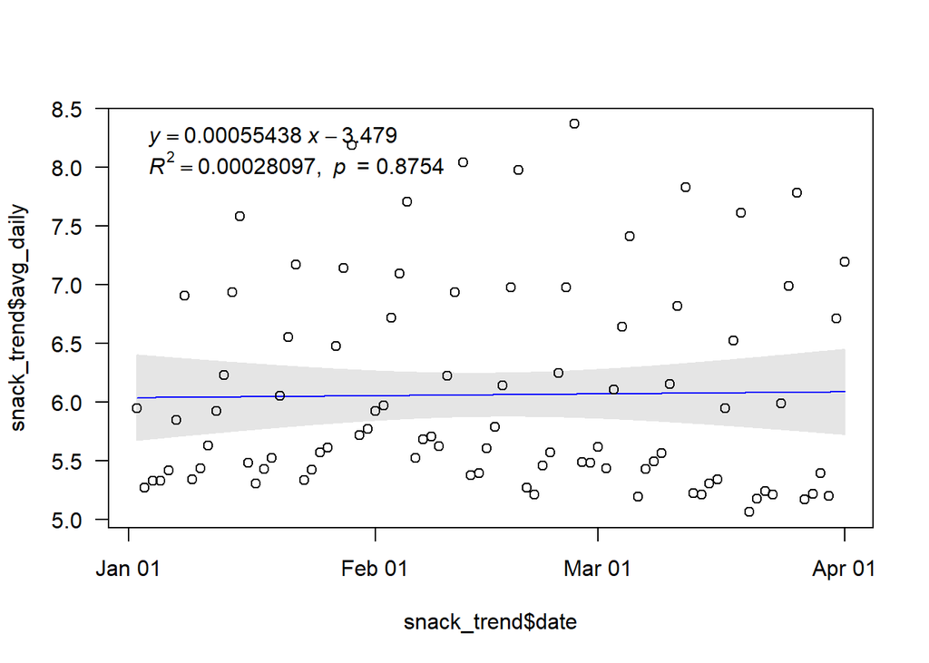

```r
snack_trend <- merged_data[type_drink_snack == 'snack',.(avg_daily=.N/uniqueN(machine)), by=.(date)][order(date)]
#plot(snack_trend$date,snack_trend$avg_daily,type = "l", main = 'Snacks per Machine per Day')

trendline(
  snack_trend$date,
  snack_trend$avg_daily,
  model = "line2P",
  Pvalue.corrected = TRUE,
  linecolor = "blue",
  lty = 1,
  lwd = 1,
  show.equation = TRUE,
  show.Rsquare = TRUE,
  show.pvalue = TRUE)
```

### Seasonal trend

2. Is there shorter time period trend as well? Is it the same for snacks and drinks? What do you think might be the cause?
- weekly seasonality for both snack and drinks
- Drinks: weekend average of 4.57 vs. weekday average of 3.39
- Snacks: weekend average of 7.25 vs. weekday average of 5.61

The vending machines are used more frequently on weekends than on the weekdays. A potential explanation for this could be that people travel more on weekends, as they have more time. Thus, vending machines, especially those in close proximity of public transport, might be more highly frequented on Saturdays and Sundays.

```r
drink_trend[,day:=weekdays(date)]
drink_dist <- drink_trend[ , .(daily_drink = mean(avg_daily)) , by=day]
drink_dist <- drink_dist %>% add_row(day = "Weekend", daily_drink =mean(drink_trend[day=="Sunday"|day=="Saturday"]$avg_daily))
drink_dist <- drink_dist %>% add_row(day = "Weekdays", daily_drink =mean(drink_trend[!(day=="Sunday"|day=="Saturday"),]$avg_daily))
drink_dist$daily_drink <- round(drink_dist$daily_drink, 2)

snack_trend[,day:=weekdays(date)]
snack_dist <- snack_trend[ , .(daily_snack = mean(avg_daily)) , by=day]
snack_dist <- snack_dist %>% add_row(day = "Weekend", daily_snack =mean(snack_trend[day=="Sunday"|day=="Saturday"]$avg_daily))
snack_dist <- snack_dist %>% add_row(day = "Weekdays", daily_snack =mean(snack_trend[!(day=="Sunday"|day=="Saturday"),]$avg_daily))
snack_dist$daily_snack <- round(snack_dist$daily_snack, 2)

merge(snack_dist, drink_dist)
```

```
##          day daily_snack daily_drink
## 1:    Friday        6.19        3.88
## 2:    Monday        5.40        3.26
## 3:  Saturday        6.82        4.41
## 4:    Sunday        7.72        4.75
## 5:  Thursday        5.55        3.39
## 6:   Tuesday        5.39        3.14
## 7: Wednesday        5.52        3.27
## 8:  Weekdays        5.61        3.39
## 9:   Weekend        7.25        4.57
```

## Question 3: Distribution of income

### Outliers

There are some extreme values in the distribution of income, which could be interpreted as outliers. This means that there are some machines that generate much more revenue than others, and this could be a result of a strategically better location of these vending machines. These outliers seem to be distributed across both small and big machines.

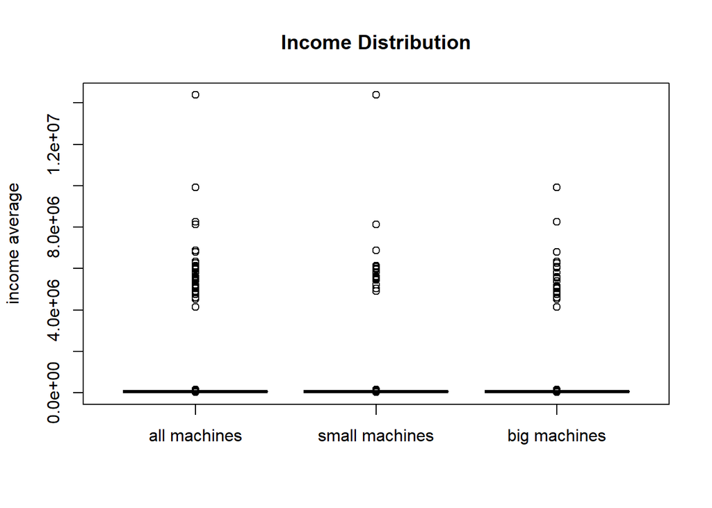

```r
income_small <- machine_data[small_machine==1, income_average]
income_big <- machine_data[small_machine==0, income_average]
boxplot(machine_data$income_average, income_small, income_big,
        main = "Income Distribution",
        names = c("all machines", "small machines", "big machines"),
        ylab = "income average")
```

```r
summary(machine_data$income_average)
```

```
##     Min.  1st Qu.   Median     Mean  3rd Qu.     Max.     NA's
##    25536    48595    53777   161672    60148 14381500      182
```

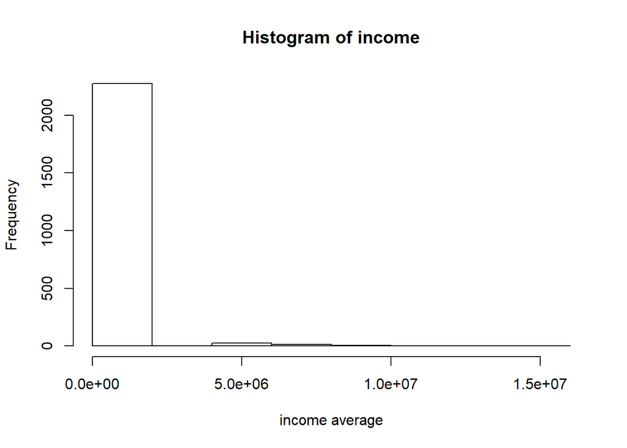

```r
hist(machine_data$income_average,
  xlab = "income average",
  main = "Histogram of income",
  breaks = 10)
```

```r
summary(machine_data$income_average); summary(income_big) ; summary(income_small)
```

```
##     Min.  1st Qu.   Median     Mean  3rd Qu.     Max.     NA's
##    25536    48595    53777   161672    60148 14381500      182
```

```
##    Min. 1st Qu.  Median    Mean 3rd Qu.    Max.    NA's
##   25536   48677   53978  144481   60654 9914100     107
```

```
##     Min.  1st Qu.   Median     Mean  3rd Qu.     Max.     NA's
##    25536    48500    53188   189462    58759 14381500       75
```

There are several ways to detect and remove outliers. One possible way is to perform a log transformation. The log transformation would include these outliers, but decrease the impact of them significantly.

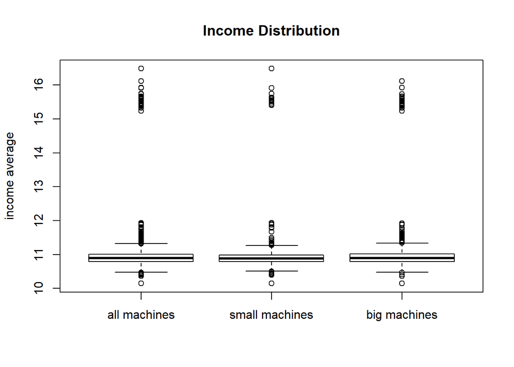

```r
boxplot(log(machine_data$income_average), log(income_small), log(income_big),
        main = "Income Distribution",
        names = c("all machines", "small machines", "big machines"),
        ylab = "income average")
```

```r
summary(log(machine_data$income_average))
```

```
##    Min. 1st Qu.  Median    Mean 3rd Qu.    Max.    NA's
##   10.15   10.79   10.89   10.99   11.00   16.48     182
```

Another method is the Interquartile range (IQR). We will employ the commonly used Interquartile range (IQR), a measure of statistical dispersion that consists of calculating the difference between the 75th and 25th percentiles or between upper and lower quartiles, such that IQR = Q3 - Q1. Then an upper and lower thresholds are set by multiplying the IQR by 1.5 (a constant used to discern outliers). Any number greater than Q3 + 1.5xIQR will be identified as an outlier. In a similar way, values smaller than Q1-1.5xIQR are also classified as outliers.

```r
Q <- quantile(machine_data$income_average, probs=c(.25, .75), na.rm = TRUE)
iqr <- IQR(machine_data$income_average, na.rm= TRUE)

up <-  Q[2]+1.5*iqr # Upper Range (beyond which datapoints are outliers)
low<- Q[1]-1.5*iqr # Lower Range

machine_data_clean <- subset(machine_data, machine_data$income_average > (Q[1] - 1.5*iqr) & machine_data$income_average < (Q[2]+1.5*iqr))

summary(machine_data_clean$income_average)
```

```
##    Min. 1st Qu.  Median    Mean 3rd Qu.    Max.
##   31570   48405   52501   53233   57054   76928
```

Moving forward, the income averages are chosen to be kept as they are, with no adjustment of outliers. This is done because we do not interpret these outliers as errors, although we are aware that this may lead to more noisy predictions in the models in question 5.

### Missing values

Missing data is a very common problem that can reduce the statistical power of our data or to produce biased estimates that will invalidate our predictions.

There are 182 NA values in the income average feature. Out of theses 182 observations, 104 of them are also NA in the train average daily passengers and train average day passengers. * no machines that have more than 1 NA * 59% of NA’s are big machines, 41% are small machines * 50% of NA’s are located close to transportation

```r
income_NA <- machine_data[is.na(income_average), ]
uniqueN(income_NA)
```

```
## [1] 182
```

```r
income_NA[ ,.(N = .N, porportion = .N/uniqueN(income_NA)) , by=location_type]
```

```
##     location_type  N porportion
## 1:         others 54  0.2967033
## 2: petrol station 36  0.1978022
## 3:      transport 92  0.5054945
```

```r
income_NA[ ,.(N = .N, porportion = .N/uniqueN(income_NA)) , by= small_machine]
```

```
##    small_machine   N porportion
## 1:             0 107  0.5879121
## 2:             1  75  0.4120879
```

```r
income_NA[ ,.(N = .N, porportion = .N/uniqueN(income_NA)) , by= machine][order(-N)]
```

```
##      machine N  porportion
##   1:       1 1 0.005494505
##   2:       2 1 0.005494505
##   3:     187 1 0.005494505
##   4:     191 1 0.005494505
##   5:     195 1 0.005494505
##  ---
## 178:    2692 1 0.005494505
## 179:    2697 1 0.005494505
## 180:    2701 1 0.005494505
## 181:    2705 1 0.005494505
## 182:    2718 1 0.005494505
```

Option 1: Remove NA’s

To deal with missing values, we can simply delete rows when a missing value occurs. Our problem is fixed, however this may affect the distribution of our data and thus the predictive capabilities of our model. The advantage of this method is that no approximation could lead to noise in the model.

```r
machine_remove_NA <- machine_data[!is.na(machine_data$income_average), ]
summary(machine_remove_NA$income_average)
```

```
##     Min.  1st Qu.   Median     Mean  3rd Qu.     Max.
##    25536    48595    53777   161672    60148 14381500
```

Option 2: Replace NA’s with Zero

```r
na_zero <- machine_data
na_zero$income_average[is.na(na_zero$income_average)] <- 0

summary(na_zero$income_average)
```

```
##     Min.  1st Qu.   Median     Mean  3rd Qu.     Max.
##        0    47406    52433   149879    58936 14381500
```

Option 3: Substitute missing values with the mean income average

A similar but more reasonable approach to deal with missing values is to replace the missing values with the mean of the income average. The advantage is that we keep these instances, but this could cause some correlation problems and affect the variability of our data.

```r
machine_data_replace_NA_mean <- machine_data
machine_data_replace_NA_mean$income_average[is.na(machine_data_replace_NA_mean$income_average)] <- mean(machine_data$income_average, na.rm = TRUE)
summary(machine_data_replace_NA_mean$income_average)
```

```
##     Min.  1st Qu.   Median     Mean  3rd Qu.     Max.
##    25536    48992    54617   161672    60984 14381500
```

Option 4: substitute missing values with average income of machine

For this particular situation, we decide to replace the missing value with the mean income average of the machine type and location type of the instance where we have a missing value. This is an improvement from the overall average in the last option, as it uses the mean of machines with more similar characteristics.

```r
w_na <- machine_data[!is.na(machine_data$income_average), ]
#w_na$income_average[is.na(w_na$income_average)]

na_mean <- machine_data
means <- w_na %>%
         filter(is.na(location_type) == F) %>%
         select(income_average, location_type, small_machine) %>%
         group_by(small_machine, location_type) %>%
         summarize(mean = mean(income_average))
small_others <- with(means, mean[small_machine == 1 & location_type == 'others'])
small_transport <- with(means, mean[small_machine == 1 & location_type == 'transport'])
small_petrol <- with(means, mean[small_machine == 1 & location_type == 'petrol station'])

big_others <- with(means, mean[small_machine == 0 & location_type == 'others'])
big_transport <- with(means, mean[small_machine == 0 & location_type == 'transport'])
big_petrol <- with(means, mean[small_machine == 0 & location_type == 'petrol station'])

na_mean$income_average[na_mean$small_machine==1
                       & na_mean$location_type == 'others'
                       & is.na(na_mean$income_average)] <- small_others
na_mean$income_average[na_mean$small_machine==1 & na_mean$location_type == 'transport' & is.na(na_mean$income_average)] <- small_transport
na_mean$income_average[na_mean$small_machine==1 & na_mean$location_type == 'petrol station' & is.na(na_mean$income_average)] <- small_petrol

na_mean$income_average[na_mean$small_machine==0 & na_mean$location_type == 'others' & is.na(na_mean$income_average)] <- big_others
na_mean$income_average[na_mean$small_machine==0 & na_mean$location_type == 'transport' & is.na(na_mean$income_average)] <- big_transport
na_mean$income_average[na_mean$small_machine==0 & na_mean$location_type == 'petrol station' & is.na(na_mean$income_average)] <- big_petrol

#na_mean$income_average[is.na(na_mean$income_average)]
summary(na_mean$income_average)
```

```
##     Min.  1st Qu.   Median     Mean  3rd Qu.     Max.
##    25536    48992    54617   160816    60984 14381500
```

## Question 4: Boxplot interpretation

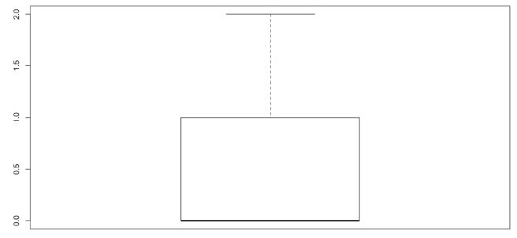

According to this boxplot the median of the number of hotels in the machine area is 0. This means that most machines do not have any hotels in their area. In this case, the median also coincides with both the minimum and the 1st quantile. The 3rd quantile is 1, while the mean of the observations is 2. This is due to the fact that most of the vending machines do not have any hotels nearby, while about half of the machines that have hotels nearby (i.e. the 4th quantile) seem to have a relatively high number of hotels nearby (the maximum is 79 hotels nearby).

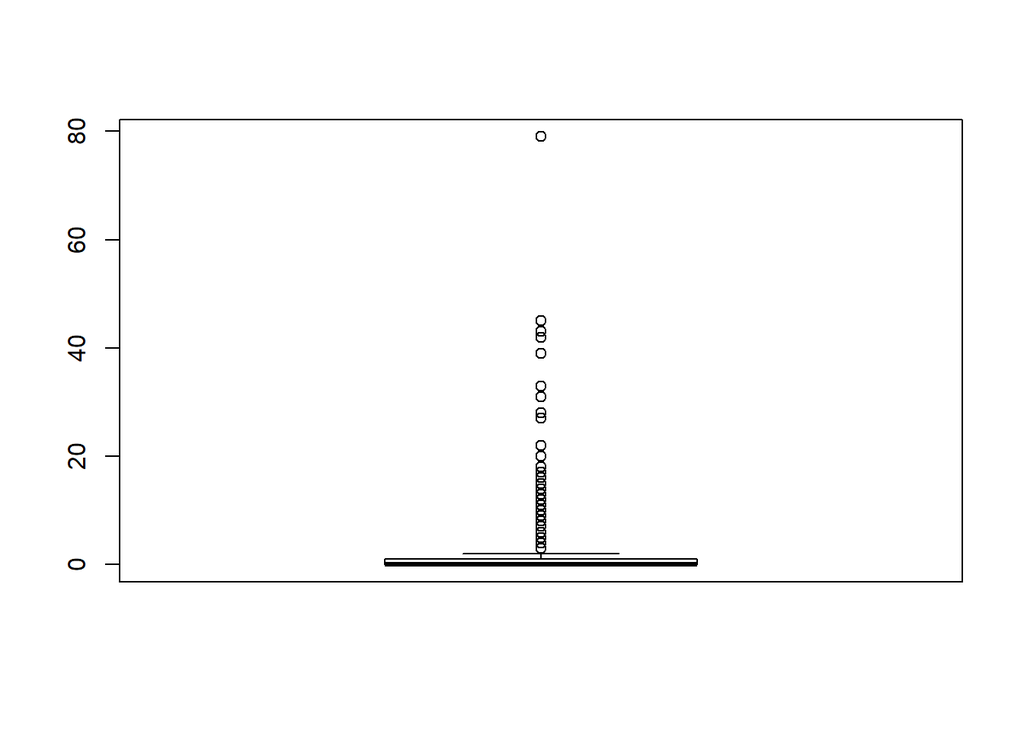

```r
boxplot(machine_data$num_hotels)
```

```r
summary(machine_data$num_hotels)
```

```
##    Min. 1st Qu.  Median    Mean 3rd Qu.    Max.
##    0.00    0.00    0.00    2.01    1.00   79.00
```

## Question 5: Location score

In this exercise we will build a location score that tells us what’s the average daily items per machine depending on the location it is placed. This model could be used to a) Decide in which locations to place new machines b) Construct a benchmark for each machine: how much should it sell according to its location? This can be used to detect problems in machines (i.e. illumination, bad placement within a station etc.)

```r
machine_data[,not_trainstation:=ifelse(is.na(train_AvgDailyPassengers),1,0)]
daily_items_sold <- merged_data[, .(.N), by= .(machine, date)]
daily_items_sold <- daily_items_sold[,.(daily_sales = mean(N)), by=machine]
model_data <- merge(machine_data, daily_items_sold)

model_data$total_number_of_routes_600[is.na(model_data$total_number_of_routes_600)] <- median(model_data$total_number_of_routes_600, na.rm=TRUE)
model_data$income_average <- na_mean$income_average
summary(model_data)
```

```
##     machine       location_type      num_vendex_nearby_300
##  Min.   :   1.0   Length:2495        Min.   : 0.000
##  1st Qu.: 801.5   Class :character   1st Qu.: 0.000
##  Median :1430.0   Mode  :character   Median : 1.000
##  Mean   :1434.5                      Mean   : 2.109
##  3rd Qu.:2061.5                      3rd Qu.: 2.000
##  Max.   :2724.0                      Max.   :64.000
##
##  train_AvgDailyPassengers train_AvgWorkingDayPassengers n_density_5km
##  Min.   :    50           Min.   :    50                Min.   :   3.482
##  1st Qu.:   950           1st Qu.:  1100                1st Qu.: 219.538
##  Median :  3800           Median :  4300                Median : 522.104
##  Mean   : 28609           Mean   : 32234                Mean   : 923.893
##  3rd Qu.: 17200           3rd Qu.: 20000                3rd Qu.:1053.455
##  Max.   :396300           Max.   :441400                Max.   :6381.860
##  NA's   :1262             NA's   :1262
##  income_average     total_number_of_routes_600   num_hotels
##  Min.   :   25536   Min.   :  1.00             Min.   : 0.00
##  1st Qu.:   48992   1st Qu.:  7.00             1st Qu.: 0.00
##  Median :   54617   Median : 16.00             Median : 0.00
##  Mean   :  160816   Mean   : 45.06             Mean   : 2.01
##  3rd Qu.:   60984   3rd Qu.: 35.00             3rd Qu.: 1.00
##  Max.   :14381500   Max.   :866.00             Max.   :79.00
##
##  num_hotels_45     small_machine    not_trainstation  daily_sales
##  Min.   : 0.0000   Min.   :0.0000   Min.   :0.0000   Min.   : 2.000
##  1st Qu.: 0.0000   1st Qu.:0.0000   1st Qu.:0.0000   1st Qu.: 4.971
##  Median : 0.0000   Median :0.0000   Median :1.0000   Median : 7.273
##  Mean   : 0.6529   Mean   :0.3844   Mean   :0.5058   Mean   : 8.647
##  3rd Qu.: 0.0000   3rd Qu.:1.0000   3rd Qu.:1.0000   3rd Qu.:10.756
##  Max.   :36.0000   Max.   :1.0000   Max.   :1.0000   Max.   :56.506
##
```

Linear regression does not work well with missing values. In this data set we have missing values for the total number of routes 600 and for the income average.

- For the missing values in the total number of routes 600, with the median of the number of routes.
- For the missing values in the income average, we replace them with the categorical mean of the instance based on machine size and location type, as described as option 4 in question 3.

### Significant variables

Do all variables show statistical significance? Which ones doesn’t? How do you know?

By checking the p-values of the coefficients, we can see that the total number of routes and number of vendex machines nearby are insignificant features.

```r
m0 <- glm( daily_sales ~ small_machine + income_average + total_number_of_routes_600
     + num_hotels_45 + not_trainstation + num_vendex_nearby_300,
    data = model_data)
summary(m0)
```

```
##
## Call:
## glm(formula = daily_sales ~ small_machine + income_average +
##     total_number_of_routes_600 + num_hotels_45 + not_trainstation +
##     num_vendex_nearby_300, data = model_data)
##
## Deviance Residuals:
##     Min       1Q   Median       3Q      Max
## -11.407   -2.914   -1.029    1.745   49.191
##
## Coefficients:
##                              Estimate Std. Error t value Pr(>|t|)
## (Intercept)                 1.069e+01  1.687e-01  63.356  < 2e-16 ***
## small_machine              -1.858e+00  1.935e-01  -9.605  < 2e-16 ***
## income_average              7.861e-07  1.198e-07   6.561 6.46e-11 ***
## total_number_of_routes_600 -2.309e-04  1.820e-03  -0.127    0.899
## num_hotels_45               3.979e-01  5.630e-02   7.067 2.04e-12 ***
## not_trainstation           -3.280e+00  1.968e-01 -16.673  < 2e-16 ***
## num_vendex_nearby_300      -2.179e-02  3.387e-02  -0.643    0.520
## ---
## Signif. codes:  0 '***' 0.001 '**' 0.01 '*' 0.05 '.' 0.1 ' ' 1
##
## (Dispersion parameter for gaussian family taken to be 22.05156)
##
##     Null deviance: 67394  on 2494  degrees of freedom
## Residual deviance: 54864  on 2488  degrees of freedom
## AIC: 14807
##
## Number of Fisher Scoring iterations: 2
```

### Linear model

Build another linear model but this time instead of using the variables “total_number_of_routes_600 use the log of that variable in base 10 calling it “log_transport”. Does this new variable show statistical significance?

Log transforming the total number of routes 600 makes the values less extreme. This is shown in the summary below of the original feature and the log transformed feature, respectively.

```r
summary(model_data$total_number_of_routes_600)
```

```
##    Min. 1st Qu.  Median    Mean 3rd Qu.    Max.
##    1.00    7.00   16.00   45.06   35.00  866.00
```

```r
model_data[,log_transport:= log(total_number_of_routes_600)]
summary(model_data$log_transport)
```

```
##    Min. 1st Qu.  Median    Mean 3rd Qu.    Max.
##   0.000   1.946   2.773   2.818   3.555   6.764
```

Create a new model that contains all variables but use the log transport instead.

- All features are significant, including the number of vendex machines nearby

```r
m1 <- glm(daily_sales ~ small_machine + income_average + log_transport
     + num_hotels_45 + not_trainstation + num_vendex_nearby_300,
        data = model_data)
summary(m1)
```

```
##
## Call:
## glm(formula = daily_sales ~ small_machine + income_average +
##     log_transport + num_hotels_45 + not_trainstation + num_vendex_nearby_300,
##     data = model_data)
##
## Deviance Residuals:
##     Min       1Q   Median       3Q      Max
## -11.142   -2.936   -0.894    1.777   49.364
##
## Coefficients:
##                         Estimate Std. Error t value Pr(>|t|)
## (Intercept)            8.720e+00  3.046e-01  28.626  < 2e-16 ***
## small_machine         -1.815e+00  1.912e-01  -9.490  < 2e-16 ***
## income_average         7.770e-07  1.184e-07   6.563 6.41e-11 ***
## log_transport          7.293e-01  9.437e-02   7.728 1.57e-14 ***
## num_hotels_45          2.920e-01  4.971e-02   5.874 4.83e-09 ***
## not_trainstation      -3.024e+00  1.972e-01 -15.338  < 2e-16 ***
## num_vendex_nearby_300 -1.023e-01  2.431e-02  -4.209 2.65e-05 ***
## ---
## Signif. codes:  0 '***' 0.001 '**' 0.01 '*' 0.05 '.' 0.1 ' ' 1
##
## (Dispersion parameter for gaussian family taken to be 21.53474)
##
##     Null deviance: 67394  on 2494  degrees of freedom
## Residual deviance: 53578  on 2488  degrees of freedom
## AIC: 14748
##
## Number of Fisher Scoring iterations: 2
```

### Cross-validation

Next, we train the model using a 80/20 train/test split of the data set and a 5-fold cross validation.

```r
# 5 fold : Train-test split
set.seed(1)
cfolds <- 5
index <- sample(1:cfolds, nrow(model_data), replace = TRUE)

for (i in 1:5){
  train <- model_data[index !=i,]
  test <- model_data[index == i,]
  final_model <- glm(daily_sales ~ small_machine + income_average + log_transport
     + num_hotels_45 + not_trainstation + num_vendex_nearby_300,
     data = train)
  pred_train1 <- predict(final_model, newdata = train, type = "response")
  pred_test1 <- predict(final_model, newdata = test, type = "response")
}

summary(final_model)
```

```
##
## Call:
## glm(formula = daily_sales ~ small_machine + income_average +
##     log_transport + num_hotels_45 + not_trainstation + num_vendex_nearby_300,
##     data = train)
##
## Deviance Residuals:
##     Min       1Q   Median       3Q      Max
## -10.849   -2.982   -0.920    1.815   49.541
##
## Coefficients:
##                         Estimate Std. Error t value Pr(>|t|)
## (Intercept)            8.674e+00  3.449e-01  25.149  < 2e-16 ***
## small_machine         -1.667e+00  2.198e-01  -7.584 5.14e-14 ***
## income_average         8.145e-07  1.270e-07   6.412 1.80e-10 ***
## log_transport          7.416e-01  1.057e-01   7.017 3.11e-12 ***
## num_hotels_45          2.633e-01  5.530e-02   4.761 2.07e-06 ***
## not_trainstation      -3.069e+00  2.258e-01 -13.592  < 2e-16 ***
## num_vendex_nearby_300 -1.230e-01  2.684e-02  -4.583 4.87e-06 ***
## ---
## Signif. codes:  0 '***' 0.001 '**' 0.01 '*' 0.05 '.' 0.1 ' ' 1
##
## (Dispersion parameter for gaussian family taken to be 22.25891)
##
##     Null deviance: 53826  on 1957  degrees of freedom
## Residual deviance: 43427  on 1951  degrees of freedom
## AIC: 11641
##
## Number of Fisher Scoring iterations: 2
```

### Small machines

How many daily items less do small machines sell all other factors remaining equal?

```r
final_model$coefficients["small_machine"]
```

```
## small_machine
##     -1.667252
```

### Number of machines nearby

What effect on machine sales does having other nearby machines all other factors remaining equal?

With other machines nearby and assuming all other factors remain the same, machine sales decrease by an average of 0.1229905 per day.

```r
final_model$coefficients["num_vendex_nearby_300"]
```

```
## num_vendex_nearby_300
##            -0.1229905
```

### Top and bottom ratio

Ranking all machines according to the final_model, what are the real daily sales of the top20% machines with respect to your model prediction? And the real daily sales of the bottom20% machines according to your model? What’s the top20%/bottom20% ratio?

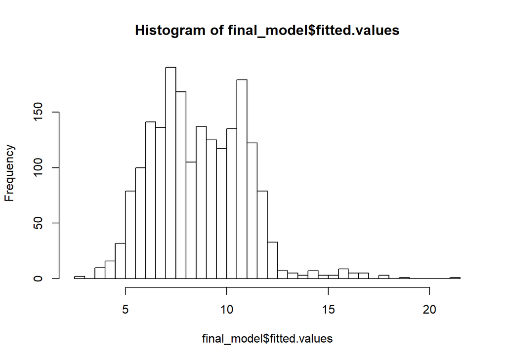

```r
hist(final_model$fitted.values, breaks = 40)
```

```r
predictions <- c(predict(final_model, model_data))
real <- c(model_data$daily_sales)

comparison <- data.table(predictions, real)
comparison$ratio <- comparison$predictions/comparison$real
comparison$difference <- comparison$predictions - comparison$real

comparison <- comparison[order(rank(predictions), decreasing = T)]
```

Top 20% predictions

```r
comparison[1:(0.2*length(comparison$predictions)),]
```

```
##      predictions      real     ratio difference
##   1:    21.06803 15.761364 1.3366882   5.306665
##   2:    18.84792 15.033333 1.2537421   3.814590
##   3:    17.93583 19.166667 0.9357825  -1.230835
##   4:    17.55491 20.744444 0.8462465  -3.189530
##   5:    17.55491 32.977778 0.5323256 -15.422863
##  ---
## 495:    10.72366 20.722222 0.5174958  -9.998560
## 496:    10.72356  7.640449 1.4035245   3.083109
## 497:    10.72260 14.931818 0.7181044  -4.209214
## 498:    10.72243 13.533333 0.7922975  -2.810907
## 499:    10.72243  6.921348 1.5491817   3.801078
```

Bottom 20% predictions

```r
comparison[(0.8*length(comparison$predictions)):(length(comparison$predictions))]
```

```
##      predictions      real     ratio  difference
##   1:    6.506086  3.760000 1.7303420   2.7460859
##   2:    6.495213  5.797619 1.1203243   0.6975942
##   3:    6.490530  4.266667 1.5212179   2.2238632
##   4:    6.490012 13.386364 0.4848226  -6.8963518
##   5:    6.481152  2.934426 2.2086606   3.5467255
##  ---
## 496:    3.978500  4.263889 0.9330685  -0.2853887
## 497:    3.978202  3.666667 1.0849642   0.3115355
## 498:    3.971950  3.557377 1.1165390   0.4145730
## 499:    2.930983 12.966667 0.2260398 -10.0356837
## 500:    2.930983  3.776119 0.7761892  -0.8451364
```

```r
top20 <- mean(comparison$ratio[1:(0.2*length(comparison))])
top20
```

```
## [1] 1.336688
```

```r
bottom20 <- mean(comparison$ratio[(0.8*length(comparison)):(length(comparison))])
bottom20
```

```
## [1] 0.9357825
```

The top20%/bottom20% ratio

```r
top20/bottom20
```

```
## [1] 1.428418
```

#### Choice

Given the following 2 locations for a big machine: i. Supermarket entrance, 2 nearby hotels of 4 stars, 20 transport routes, no nearby machines ii. Transport station, no nearby hotels of 4 or 5 stars, 10 transport routes nearby, 3 nearby Vendex machines Which location would you choose and why?

```r
option1 <- predict(final_model,
                   data.frame(small_machine=0,income_average=0,log_transport=log(20,base=10),num_hotels_45=2,
                              num_vendex_nearby_300=0,not_trainstation=0))
option2 <- predict(final_model,
                   data.frame(small_machine=0,income_average=0,log_transport=log(10,base=10),num_hotels_45=0,
                                num_vendex_nearby_300=3,not_trainstation=1))

option1
```

```
##        1
## 10.16578
```

```r
option2
```

```
##        1
## 5.978487
```